# rozwiazanie

```python
from sklearn.linear_model import LinearRegression
from sklearn.svm import SVR
from sklearn.ensemble import RandomForestRegressor
```

```python
from sklearn.model_selection import RandomizedSearchCV
import sklearn
from sklearn.externals.joblib import parallel_backend
from sklearn import preprocessing
```

```
/home/pawel/anaconda3/lib/python3.6/site-packages/sklearn/externals/joblib/__init__.py:15: DeprecationWarning: sklearn.externals.joblib is deprecated in 0.21 and will be removed in 0.23. Please import this functionality directly from joblib, which can be installed with: pip install joblib. If this w…
  warnings.warn(msg, category=DeprecationWarning)
```

```python
import pandas as pd
import numpy as np
from collections import defaultdict
from sklearn.impute import SimpleImputer
import seaborn as sns
from scipy.stats import norm
from scipy import stats
import matplotlib.pyplot as plt
```

Wyłączone warningi dla seaborn:

```python
import warnings
warnings.filterwarnings('ignore')
```

# House prices challenge

## Dostępne dane

```python
! ls ./data/
```

```
data_description.txt  sample_submission.csv  test.csv  train.csv
```

### Zestaw treningowy

```python
training_raw = pd.read_csv('./data/train.csv')
```

```python
training_raw.head()
```

|  | Id | MSSubClass | MSZoning | LotFrontage | LotArea | Street | Alley | LotShape | LandContour | Utilities | ... | PoolArea | PoolQC | Fence | MiscFeature | MiscVal | MoSold | YrSold | SaleType | SaleCondition | SalePrice |
| --- | --- | --- | --- | --- | --- | --- | --- | --- | --- | --- | --- | --- | --- | --- | --- | --- | --- | --- | --- | --- | --- |
| 0 | 1 | 60 | RL | 65.0 | 8450 | Pave | NaN | Reg | Lvl | AllPub | ... | 0 | NaN | NaN | NaN | 0 | 2 | 2008 | WD | Normal | 208500 |
| 1 | 2 | 20 | RL | 80.0 | 9600 | Pave | NaN | Reg | Lvl | AllPub | ... | 0 | NaN | NaN | NaN | 0 | 5 | 2007 | WD | Normal | 181500 |
| 2 | 3 | 60 | RL | 68.0 | 11250 | Pave | NaN | IR1 | Lvl | AllPub | ... | 0 | NaN | NaN | NaN | 0 | 9 | 2008 | WD | Normal | 223500 |
| 3 | 4 | 70 | RL | 60.0 | 9550 | Pave | NaN | IR1 | Lvl | AllPub | ... | 0 | NaN | NaN | NaN | 0 | 2 | 2006 | WD | Abnorml | 140000 |
| 4 | 5 | 60 | RL | 84.0 | 14260 | Pave | NaN | IR1 | Lvl | AllPub | ... | 0 | NaN | NaN | NaN | 0 | 12 | 2008 | WD | Normal | 250000 |

5 rows × 81 columns

```python
training_raw.tail()
```

|  | Id | MSSubClass | MSZoning | LotFrontage | LotArea | Street | Alley | LotShape | LandContour | Utilities | ... | PoolArea | PoolQC | Fence | MiscFeature | MiscVal | MoSold | YrSold | SaleType | SaleCondition | SalePrice |
| --- | --- | --- | --- | --- | --- | --- | --- | --- | --- | --- | --- | --- | --- | --- | --- | --- | --- | --- | --- | --- | --- |
| 1455 | 1456 | 60 | RL | 62.0 | 7917 | Pave | NaN | Reg | Lvl | AllPub | ... | 0 | NaN | NaN | NaN | 0 | 8 | 2007 | WD | Normal | 175000 |
| 1456 | 1457 | 20 | RL | 85.0 | 13175 | Pave | NaN | Reg | Lvl | AllPub | ... | 0 | NaN | MnPrv | NaN | 0 | 2 | 2010 | WD | Normal | 210000 |
| 1457 | 1458 | 70 | RL | 66.0 | 9042 | Pave | NaN | Reg | Lvl | AllPub | ... | 0 | NaN | GdPrv | Shed | 2500 | 5 | 2010 | WD | Normal | 266500 |
| 1458 | 1459 | 20 | RL | 68.0 | 9717 | Pave | NaN | Reg | Lvl | AllPub | ... | 0 | NaN | NaN | NaN | 0 | 4 | 2010 | WD | Normal | 142125 |
| 1459 | 1460 | 20 | RL | 75.0 | 9937 | Pave | NaN | Reg | Lvl | AllPub | ... | 0 | NaN | NaN | NaN | 0 | 6 | 2008 | WD | Normal | 147500 |

5 rows × 81 columns

Analizę danych treningowych zaczynam od sprawdzenia brakujących wartości. Jeżeli dana zmienna zawiera ich więcej niż 10% usuwam tą zmienną z zestawu i nie biorę jej pod uwagę w dalszej analizie.

```python
training_raw.shape[0]
```

```
1460
```

```python
total_missing = training_raw.isnull().sum().sort_values(ascending=False)
percentage_missing = (training_raw.isnull().sum()/training_raw.shape[0]).sort_values(ascending=False)
missing_data = pd.concat([total_missing, percentage_missing], axis=1, keys=['Total', 'Percentage'])
missing_data.head(10)
```

|  | Total | Percentage |
| --- | --- | --- |
| PoolQC | 1453 | 0.995205 |
| MiscFeature | 1406 | 0.963014 |
| Alley | 1369 | 0.937671 |
| Fence | 1179 | 0.807534 |
| FireplaceQu | 690 | 0.472603 |
| LotFrontage | 259 | 0.177397 |
| GarageCond | 81 | 0.055479 |
| GarageType | 81 | 0.055479 |
| GarageYrBlt | 81 | 0.055479 |
| GarageFinish | 81 | 0.055479 |

Zmienne, które zostaną usunięte to:

```python
cols_to_del = missing_data.loc[missing_data['Percentage'] >= 0.1].index.tolist()
cols_to_del
```

```
['PoolQC', 'MiscFeature', 'Alley', 'Fence', 'FireplaceQu', 'LotFrontage']
```

```python
for col in cols_to_del:
    training_raw.drop(col, axis=1, inplace=True)
```

Sprawdzam zmienne, które mają braki niższe niż 10%:

```python
missing_data.loc[(missing_data['Percentage'] < 0.1) & (missing_data['Percentage'] > 0)]
```

|  | Total | Percentage |
| --- | --- | --- |
| GarageCond | 81 | 0.055479 |
| GarageType | 81 | 0.055479 |
| GarageYrBlt | 81 | 0.055479 |
| GarageFinish | 81 | 0.055479 |
| GarageQual | 81 | 0.055479 |
| BsmtExposure | 38 | 0.026027 |
| BsmtFinType2 | 38 | 0.026027 |
| BsmtFinType1 | 37 | 0.025342 |
| BsmtCond | 37 | 0.025342 |
| BsmtQual | 37 | 0.025342 |
| MasVnrArea | 8 | 0.005479 |
| MasVnrType | 8 | 0.005479 |
| Electrical | 1 | 0.000685 |

Pojawia się zmienna dotycząca garażu. Rzuca się w oczy fakt, że każda ze zmiennych ma dokładnie tą samą liczbę braków - być może chodzi o te same obserwacje (o tych samych `Id`)?

```python
garage_index_dict = defaultdict(int)

for col_name in missing_data.filter(regex='Garage*', axis=0).loc[missing_data['Percentage'] > 0].index:
    garage_index_dict[col_name] = set(training_raw.loc[training_raw[col_name].isna()].index)
```

```python
common_indices = set.intersection(*list(garage_index_dict.values()))
```

```python
len(common_indices)
```

```
81
```

Okazuje się, że wszystkie obserwacje, które mają brakującą wartość w `GarageType` mają także brakującą wartość w pozostałych cechach dotyczących garażu.

Warto utworzyć zmienną `hasGarage`, która będzie informowała czy nieruchomość posiada garaż:

```python
training_raw['hasGarage'] = training_raw['GarageType'].apply(lambda x: not pd.isna(x))
```

Aby uzupełnić braki w zmiennej informującej o roku wybudowania garażu `GarageYrBlt` uzupełniam brakujące wartości medianą:

```python
training_raw['GarageYrBlt'].fillna(training_raw['GarageYrBlt'].median(), inplace=True)
```

Braki w pozostałych garażowych zmiennych wypełniam tworząc nowy poziom `'None_empty'`:

```python
values_to_fill = {'GarageCond': 'None_empty', 'GarageFinish': 'None_empty', 'GarageQual': 'None_empty', 'GarageType': 'None_empty'}
training_raw.fillna(value=values_to_fill, inplace=True)
```

Sprawdzam teraz zmienne dotyczące piwnicy, w której także występują braki:

```python
bsmt_index_dict = defaultdict(int)

for col_name in missing_data.filter(regex='Bsmt*', axis=0).loc[missing_data['Percentage'] > 0].index:
    bsmt_index_dict[col_name] = set(training_raw.loc[training_raw[col_name].isna()].index)

common_indices_bsmt = set.intersection(*list(bsmt_index_dict.values()))

len(common_indices_bsmt)
```

```
37
```

```python
bsmt_index_dict['BsmtFinType2'] - bsmt_index_dict['BsmtCond']
```

```
{332}
```

W przypadku piwnicy nie było jednoznacznego przypadku jak dla garażu. Okazuje się, że poniższa obserwacja nie ma wpisanej wartości dla dodatkowej zmiennej `BsmtFinType2`:

```python
training_raw.iloc[332].filter(regex='Bsmt*', axis=0)
```

```
BsmtQual          Gd
BsmtCond          TA
BsmtExposure      No
BsmtFinType1     GLQ
BsmtFinSF1      1124
BsmtFinType2     NaN
BsmtFinSF2       479
BsmtUnfSF       1603
TotalBsmtSF     3206
BsmtFullBath       1
BsmtHalfBath       0
Name: 332, dtype: object
```

Aby zapobiec błędom na etapie dopasowywania modeli wartości `NaN` dla kolumn `Bsmt*` wypełniam przy pomocy napisu:

```python
values_to_fill_bsmt = defaultdict(str)

for col_name in missing_data.filter(regex='Bsmt*', axis=0).loc[missing_data['Percentage'] > 0].index:
    values_to_fill_bsmt[col_name] = 'None_empty'

training_raw.fillna(value=values_to_fill_bsmt, inplace=True)
```

W przypadku zmiennych `MasVnr*` sprawdzam ręcznie ramkę danych:

```python
training_raw.filter(regex='MasVnr*', axis=1).loc[training_raw['MasVnrType'].isna()]
```

|  | MasVnrType | MasVnrArea |
| --- | --- | --- |
| 234 | NaN | NaN |
| 529 | NaN | NaN |
| 650 | NaN | NaN |
| 936 | NaN | NaN |
| 973 | NaN | NaN |
| 977 | NaN | NaN |
| 1243 | NaN | NaN |
| 1278 | NaN | NaN |

W tym przypadku brakujące wartości dla zmiennej kategorycznej `MasVnrType` zamieniam na tekst, co ma służyć zapobieżeniu błędu w później dopasowywanych modelach, a braki dla zmiennej liczbowej `MasVnrArea` na 0.

```python
values_to_fill = {'MasVnrType': 'None_empty', 'MasVnrArea': 0}
training_raw.fillna(value=values_to_fill, inplace=True)
```

W przypadku brakującej obserwacji dla `Electrical` usuwam obserwację:

```python
training_raw.drop(index=np.where(training_raw['Electrical'].isna())[0], inplace=True)
```

W danych nie ma już braków:

```python
training_raw.isna().isna().sum().sum()
```

```
0
```

## TODO

Czy stworzyć zestaw walidacyjny?

```python
test_raw = pd.read_csv('./data/test.csv')
```

```python
test_raw.isna().isna().sum().sum()
```

```
0
```

## Wybór zmiennych

W przerobionym zestawie trenigowym znajduje się tyle zmiennych (mniej 1, żeby uwzględnić unikalne `Id` obserwacji):

```python
len(training_raw.columns)-1
```

```
75
```

Zaczynam od sprawdzenia zmiennej objaśnianej, którą jest `SalePrice`:

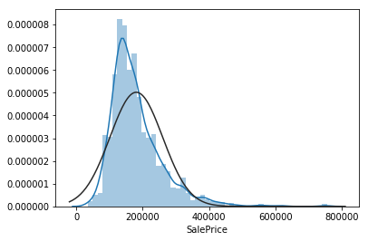

```python
sns.distplot(training_raw['SalePrice'], fit=norm)
```

W swoje pierwotnej postaci odstaje od rozkładu normalnego, który wyrysowany jest czarną linią. Sprawdzam czy występują wartości równe 0:

```python
training_raw['SalePrice'].describe()
```

```
count      1459.000000
mean     180930.394791
std       79468.964025
min       34900.000000
25%      129950.000000
50%      163000.000000
75%      214000.000000
max      755000.000000
Name: SalePrice, dtype: float64
```

Jako, że wartość zero nie występuje mogę dokonać transformacji logarytmem:

```python
training_raw['SalePriceLog'] = np.log(training_raw['SalePrice'])
```

Rozkład dla transformowanej zmiennej wygląda prawie jak rozkład normalny:

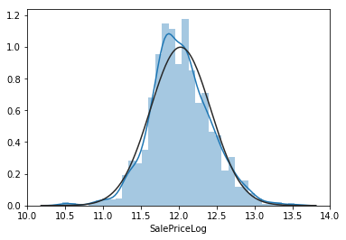

```python
sns.distplot(training_raw['SalePriceLog'], fit=norm)
```

Sprawdzam dodatokowo rozkład teoretyczny (czerwona linia) oraz zaobserwowany:

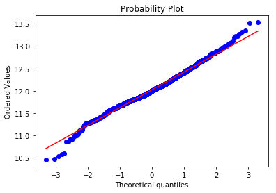

```python
fig = plt.figure()
res = stats.probplot(training_raw['SalePriceLog'], plot=plt)
```

### Związki pomiędzy zmienną zależną a niezależnymi

Zaczynam od macierzy, która przedstawia zmienne i korelacje pomiędzy nimi. Widać silną korelację pomiędzy:

Interesuje mnie wartość bezwzględna współczynnika korelacji:

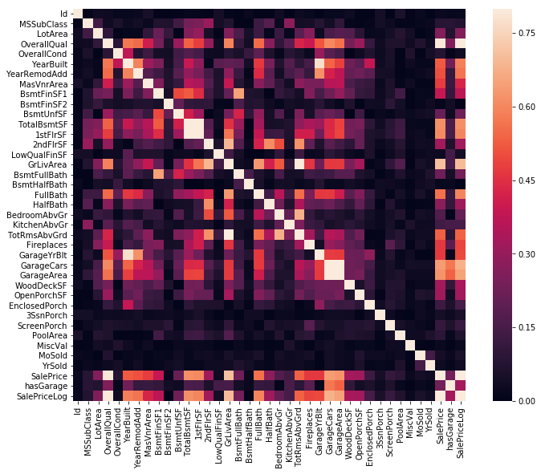

```python
corrmat = training_raw.corr().abs()
f, ax = plt.subplots(figsize=(12, 9))
sns.heatmap(corrmat, vmax=.8, square=True)
```

```python
s = corrmat.unstack()
s = s[s<1]
so = s.sort_values(ascending=False)
```

Sprawdzam najbardziej ze sobą korelujące zmienne. Na tym etapie zaznaczam takie grupy zmiennych przez które niosą podobną informację:

1. `GarageCars` oraz `GarageArea` - im większa powierzchnia garażu tym więcej samochodów możemy trzymać w garażu.
2. `GrLivArea` oraz `TotRmsAbvGrd` - im więcej pokojów jakimś standardzie tym większa ich łączna powierzchnia.
3. `TotalBsmtSF` oraz `1stFlrSF` - im większa powierzchnia pierwszego piętra tym większa powierzchnia całości nieruchomości.
4. `YearBuilt` oraz `GarageYrBlt` - dom i garaż zapewne wybudowane w tym samym roku.
5. `GrLivArea` oraz `2ndFlrSF` - im większa powierzchnia drugiego piętra tym większa powierzchnia przestrzeni mieszkalnej.
6. `TotRmsAbvGrd` oraz `BedroomAbvGr` - im więcej sypialni tym więcej pokoi.
7. `2ndFlrSF` oraz `HalfBath` - im większe drugie piętro pod względem powierzchnie tym więcej (pół)łazienek można tam wcisnąć.

```python
so[so>0.6]
```

```
SalePrice     SalePriceLog    0.948384
SalePriceLog  SalePrice       0.948384
GarageCars    GarageArea      0.882613
GarageArea    GarageCars      0.882613
TotRmsAbvGrd  GrLivArea       0.825576
GrLivArea     TotRmsAbvGrd    0.825576
TotalBsmtSF   1stFlrSF        0.819393
1stFlrSF      TotalBsmtSF     0.819393
OverallQual   SalePriceLog    0.817368
SalePriceLog  OverallQual     0.817368
SalePrice     OverallQual     0.791069
OverallQual   SalePrice       0.791069
YearBuilt     GarageYrBlt     0.776974
GarageYrBlt   YearBuilt       0.776974
SalePrice     GrLivArea       0.708618
GrLivArea     SalePrice       0.708618
SalePriceLog  GrLivArea       0.700941
GrLivArea     SalePriceLog    0.700941
              2ndFlrSF        0.687726
2ndFlrSF      GrLivArea       0.687726
GarageCars    SalePriceLog    0.680645
SalePriceLog  GarageCars      0.680645
BedroomAbvGr  TotRmsAbvGrd    0.676613
TotRmsAbvGrd  BedroomAbvGr    0.676613
GarageArea    SalePriceLog    0.650916
SalePriceLog  GarageArea      0.650916
BsmtFullBath  BsmtFinSF1      0.649025
BsmtFinSF1    BsmtFullBath    0.649025
GarageCars    SalePrice       0.640473
SalePrice     GarageCars      0.640473
FullBath      GrLivArea       0.630283
GrLivArea     FullBath        0.630283
GarageArea    SalePrice       0.623423
SalePrice     GarageArea      0.623423
TotRmsAbvGrd  2ndFlrSF        0.616400
2ndFlrSF      TotRmsAbvGrd    0.616400
GarageYrBlt   YearRemodAdd    0.616113
YearRemodAdd  GarageYrBlt     0.616113
TotalBsmtSF   SalePrice       0.613905
SalePrice     TotalBsmtSF     0.613905
SalePriceLog  TotalBsmtSF     0.612642
TotalBsmtSF   SalePriceLog    0.612642
2ndFlrSF      HalfBath        0.609551
HalfBath      2ndFlrSF        0.609551
1stFlrSF      SalePrice       0.605968
SalePrice     1stFlrSF        0.605968
GarageCars    OverallQual     0.600991
OverallQual   GarageCars      0.600991
dtype: float64
```

Sprawdzam jakie zmienne korelują ze zmienną zależną:

1. `OverallQual`
2. `GrLivArea`
3. `GarageCars`
4. `GarageArea`
5. `TotalBsmtSF`
6. `1stFlrSF`
7. `FullBath`
8. `YearBuilt`
9. `YearRemodAdd`
10. `TotRmsAbvGrd`

```python
mi = so[so > 0.5].filter(like='SalePrice').index
mi.names = ['level_1', 'level_2']
vars1 = set(mi.get_level_values('level_1'))
vars2 = set(mi.get_level_values('level_2'))
```

Zmienne, które rozważę:

```python
vars_to_consider = list(vars1.union(vars2))
vars_to_consider
```

```
['YearBuilt',
 'GarageArea',
 'TotRmsAbvGrd',
 '1stFlrSF',
 'FullBath',
 'SalePriceLog',
 'GrLivArea',
 'OverallQual',
 'YearRemodAdd',
 'TotalBsmtSF',
 'SalePrice',
 'GarageCars']
```

Analiza poniższej macierzy wskazuje na to, że powinienem usunąć zmienną `GarageCars`, `1stFlrSF`, `TotRmsAbvGrd`

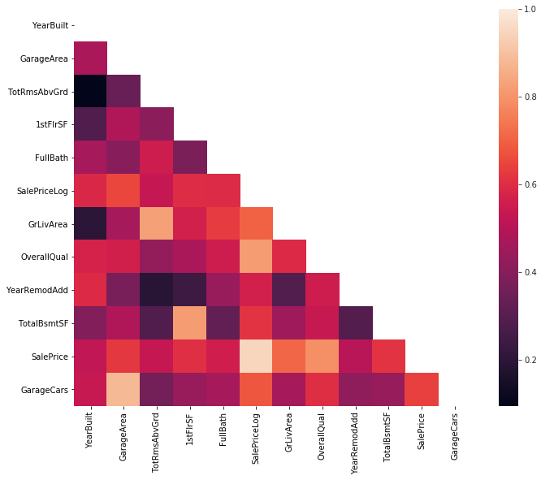

```python
corrmat_chosen_vars = training_raw[vars_to_consider].corr()
mask = np.zeros_like(corrmat_chosen_vars)
mask[np.triu_indices_from(mask)] = True
f, ax = plt.subplots(figsize=(12, 9))
with sns.axes_style("white"):
    ax = sns.heatmap(corrmat_chosen_vars, mask=mask, vmax=1, square=True)
```

```python
vars_to_consider.remove('GarageCars')
vars_to_consider.remove('1stFlrSF')
vars_to_consider.remove('TotRmsAbvGrd')
```

Teraz sprawdzam rozkłady parami (zmienna zależna - zmienna niezależna) w celu zastosowania ewentualnej transformacji:

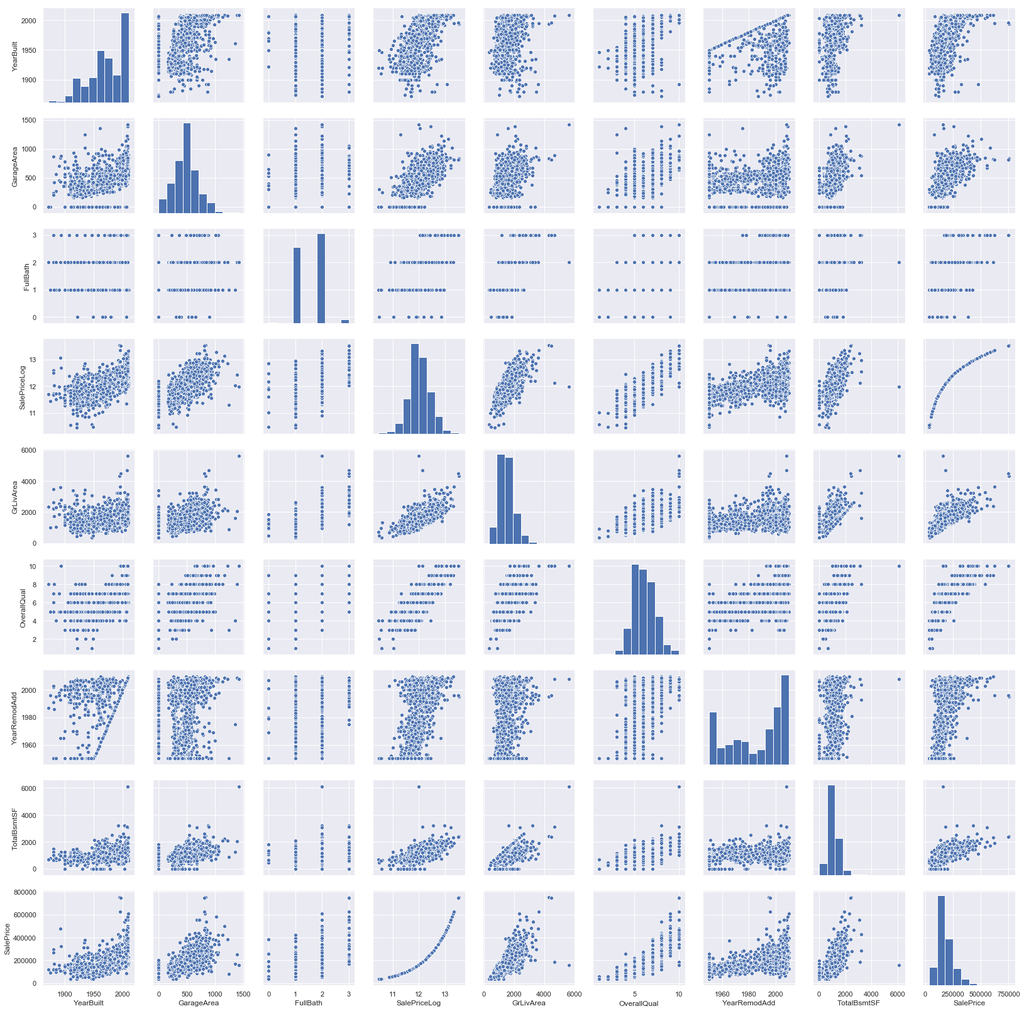

```python
sns.set()
sns.pairplot(training_raw[vars_to_consider], size = 2.5)
plt.show();
```

Będę przewidywał transformowaną zmienną `SalePriceLog`. Sprawdzam obserwacje odstające dla zmiennych `TotalBsmtSF` oraz `GrLivArea`:

```
'c' argument looks like a single numeric RGB or RGBA sequence, which should be avoided as value-mapping will have precedence in case its length matches with 'x' & 'y'.  Please use a 2-D array with a single row if you really want to specify the same RGB or RGBA value for all points.
```

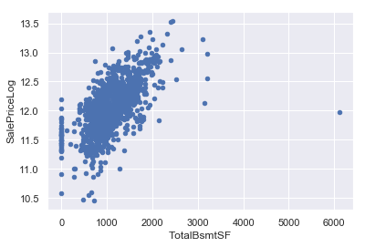

```python
training_raw.plot.scatter(x='TotalBsmtSF', y='SalePriceLog')
```

```python
training_raw.loc[training_raw['TotalBsmtSF'] > 6000][vars_to_consider]
```

|  | YearBuilt | GarageArea | FullBath | SalePriceLog | GrLivArea | OverallQual | YearRemodAdd | TotalBsmtSF | SalePrice |
| --- | --- | --- | --- | --- | --- | --- | --- | --- | --- |
| 1298 | 2008 | 1418 | 2 | 11.982929 | 5642 | 10 | 2008 | 6110 | 160000 |

```python
index = training_raw.loc[training_raw['TotalBsmtSF'] > 6000][vars_to_consider].index
training_raw.drop(index, inplace=True)
```

```
'c' argument looks like a single numeric RGB or RGBA sequence, which should be avoided as value-mapping will have precedence in case its length matches with 'x' & 'y'.  Please use a 2-D array with a single row if you really want to specify the same RGB or RGBA value for all points.
```

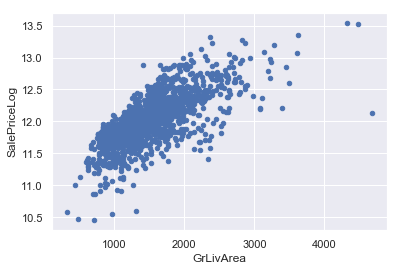

```python
training_raw.plot.scatter(x='GrLivArea', y='SalePriceLog')
```

```python
training_raw.loc[(training_raw['GrLivArea'] > 4000) & (training_raw['SalePriceLog'] > 12) & (training_raw['SalePriceLog'] < 12.5)][vars_to_consider]
```

|  | YearBuilt | GarageArea | FullBath | SalePriceLog | GrLivArea | OverallQual | YearRemodAdd | TotalBsmtSF | SalePrice |
| --- | --- | --- | --- | --- | --- | --- | --- | --- | --- |
| 523 | 2007 | 884 | 3 | 12.126759 | 4676 | 10 | 2008 | 3138 | 184750 |

Tą obserwację też usuwam:

```python
index = training_raw.loc[(training_raw['GrLivArea'] > 4000) & (training_raw['SalePriceLog'] > 12) & (training_raw['SalePriceLog'] < 12.5)][vars_to_consider].index
training_raw.drop(index, inplace=True)
```

```python
vars_to_consider
```

```
['YearBuilt',
 'GarageArea',
 'FullBath',
 'SalePriceLog',
 'GrLivArea',
 'OverallQual',
 'YearRemodAdd',
 'TotalBsmtSF',
 'SalePrice']
```

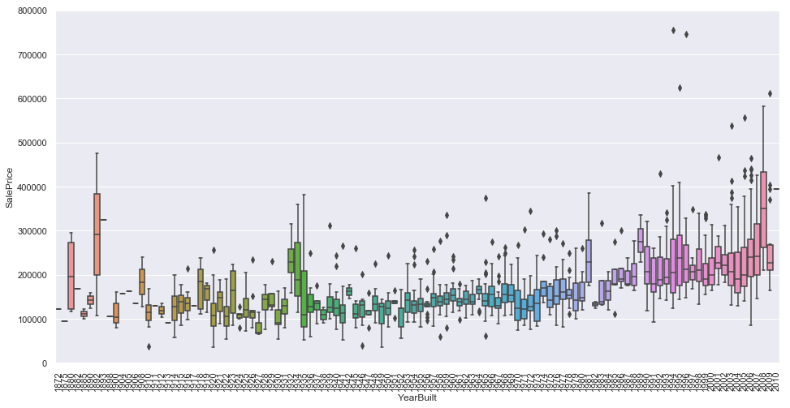

```python
data = pd.concat([training_raw['SalePrice'], training_raw['YearBuilt']], axis=1)
f, ax = plt.subplots(figsize=(16, 8))
fig = sns.boxplot(x='YearBuilt', y="SalePrice", data=data)
fig.axis(ymin=0, ymax=800000)
plt.xticks(rotation=90)
```